# Day 17 Pre-Class: Morphological operations, labelings, and (more) convolutions

[figure not shown]

### Goals for this pre-class assignment

By the end of this assignment, you should be able to:

- Understand the two main morphological operations: erosion and dilation
- Understand how the combination of these can be helpful in a number of contexts
- Label separate connected components
- Practice more convolutions, especially the one to get boundaries

### Assignment instructions

Watch the videos below, do the readings linked to below the videos, and complete the assigned programming problems. Please get started early, and come to office hours if you have any questions! Make use of Slack as well!

**This assignment is due by 11:59 p.m. the day before class,** and should be uploaded into the "Pre-class assignments" submission folder for Day 17. Submission instructions can be found at the end of the notebook.

# Part 1: Image preparation

We are going to use a different image this time: a 2D scan of two maize blades. Make sure you place `IMAG0001_rz.JPG` in the `raw` folder.

```python
from IPython.display import YouTubeVideo, HTML
import matplotlib.pyplot as plt
import numpy as np
import os
from PIL import Image
from scipy import ndimage
from skimage import filters
```

Now let's use `Image` to load the image. But this time, we are going to convert it to grayscale with the `.convert('L')` option instead of `.convert('RGB')`.

**Sidenote:** You probably noticed last assigment that we kept writting over and over again parameters `cmap = 'Greys_r', vmin=0, vmax=255`. If you are going to use the same set of parameters over and over again, you can declare them in a dictionary, and the pass that dictionary of keyword arguments (*kwargs*) with `**`. That's what `**kwargs` mean in several documentation pages: additional parameters that can be passed.

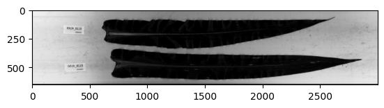

```python
imkw = {'cmap':'Greys_r', 'vmin':0, 'vmax':255}
src = '..' + os.sep + 'raw' + os.sep
filename = 'IMAG0001_rz.JPG'

with open(src + filename, "rb") as imagefile:
    picture = Image.open(imagefile)
    picture.load()
gray = np.asarray(picture.convert('L')) # convert to grayscale instead of RGB, so our image will be single-channel from the get-go

# What happens if you comment out the line below?
gray = gray.T

plt.imshow(gray, **imkw);
```

**Task:**

- Compute a histogram of the maize blades scan like in In-Class 15.
- That is, make sure the bins go from 0 to 255.
- Is there a large gap between foreground and background intensities?
- Is the image a good candidate to perform Otsu's method?

```python
# Your code
```

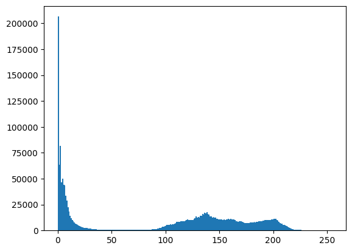

```python
## ANSWER

plt.hist(gray.ravel(), bins=range(0,256));
```

You probably noticed two things between the histogram and the image itself:

- There is a large gap between foreground and background pixel intensities, which means there is a high chance Otsu is a good choice.
- The foreground (the blades) actually are much *darker* than the background, which is *lighter*.

It is convenient to stick to the convention that background is dark (0-valued) and foreground is light. We can easily invert the intensities by doing `gray.max() - gray`.

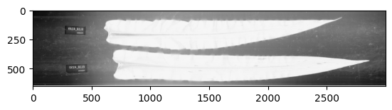

```python
# inverting colors

img = gray.max() - gray
plt.imshow(img, **imkw);
```

- We then compute Otsu for `img` and have `binary` be the binarized image
- And plot `binary`. Remember that for binarized images, the max value is `True` or `1`, so we don't need `imkw` in this case.

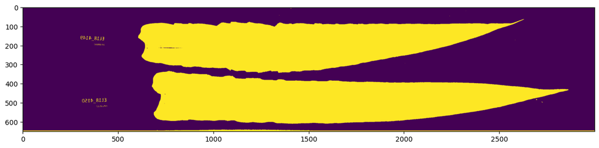

```python
thr = filters.threshold_otsu(img)
binary = img > thr
fig, ax = plt.subplots(1,1, figsize=(15,20), sharex=True, sharey=True)
ax.imshow(binary);
```

## Part 2: Morphological Operations

We notice that Otsu did a good job as expected from the histogram. However, it is not perfect. Can you notice some problems? You might need to make the image vertical (again with `.T`) so the plot is even larger.

Some issues:

- The text of the labels is still there
- Near the tip of one of the blades, there are some stray background pixels that were wrongly labeled as foreground.
- Part of midvein in one of the blades was wrongly labeled as background and deleted.
- Part of the margin was also wrongly labeled as foreground.

Fortunately, we can solve most of these issues with a combination of the two main morphological operations: dilation and erosion. The key insight is that stray pixels and stray holes are very *small* compared to the main objects of interest (the blades), which are *large*.

Watch the short video below for a general overview of these two operations:

```python
YouTubeVideo('uUweXBmm978', width=640, height=360)
```

[video not shown]

Also watch this other explanation of erosion and dilation. Feel free to fast-forward the middle-third of the video that goes into coding the operations in Matlab (below we are going to dilate and erode with Python).

```python
YouTubeVideo('yM0tqRhpxoM', width=640, height=360)
```

[video not shown]

And finally, watch this explanation of closing and opening to see how simple combinations of erosions and dilations can be quite powerful to correct binarized images. Again, feel free to fast-forward the middle-third that goes into Matlab.

```python
YouTubeVideo('E_vU1Wd7Ks8', width=640, height=360)
```

[video not shown]

In your own words: What is erosion? What is dilation? Why is opening helpful? Why is closing helpful? Do you see any resemblance between a dilation and a maximum filter? And between an erosion and a minimum filter?

*Your answer*

### 2.1 Our first erosion

Let's go back to our maize image. Let's remove the pixels corresponding to the label by first eroding the image. Ideally, after the erosion these stray pixels should be gone, so when we dilate, they don't grow back.

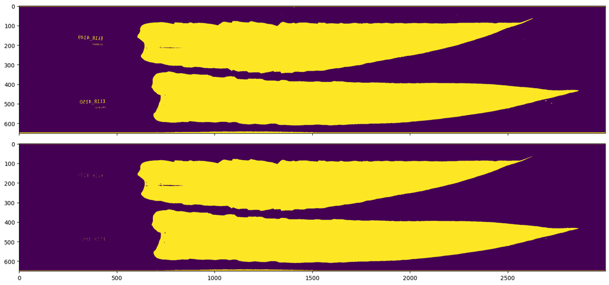

```python
# Make sure you understand the code and its parameters
# Add labels

its = 1
erode = ndimage.binary_erosion(binary, iterations=its)
fig, ax = plt.subplots(2,1, figsize=(15,7), sharex=True, sharey=True)
ax[0].imshow(binary);
ax[1].imshow(erode);
fig.tight_layout();
```

### 2.2 Our first dilation (and opening)

Now let's recover the original blade shapes by dilating by the *same number* of iterations. This erosion+dilation combination is also our first opening.

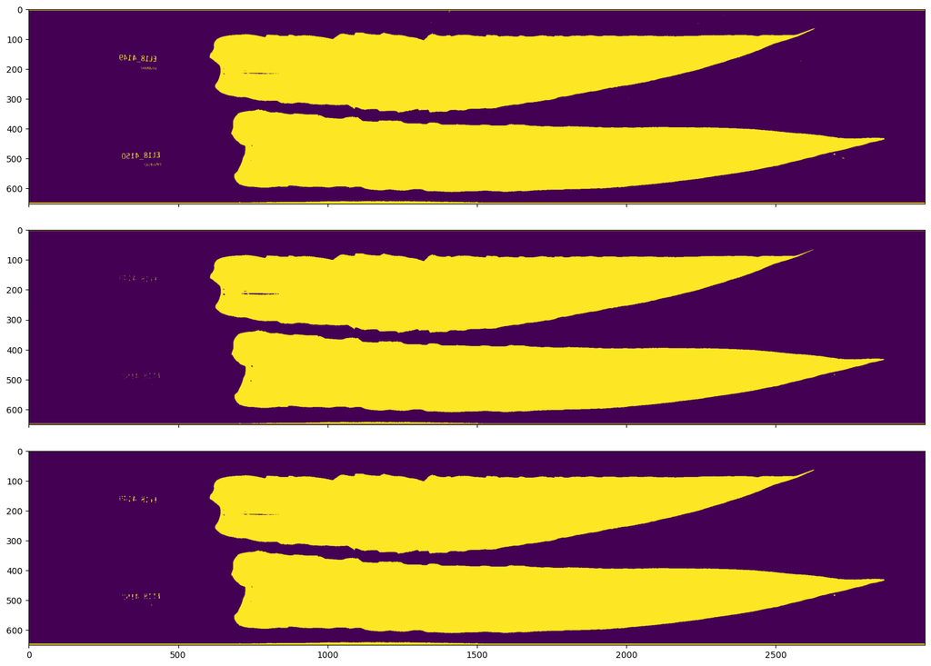

```python
# Make sure you understand the code and its parameters
# Add labels

dilate = ndimage.binary_dilation(erode, iterations=its)
fig, ax = plt.subplots(3,1, figsize=(15,11), sharex=True, sharey=True)
ax[0].imshow(binary);
ax[1].imshow(erode);
ax[2].imshow(dilate)
fig.tight_layout();
```

The dilated (opened) image should look like the initial, binarized one *minus* the label, border, and other stray pixels. If they are still showing up, you need to increase the iterations for the erosion (and also increase the iterations for the following dilation.)

### 2.3 Our second dilation

Now let's dilate again, this time, to fix the "holes" in one of the blades.

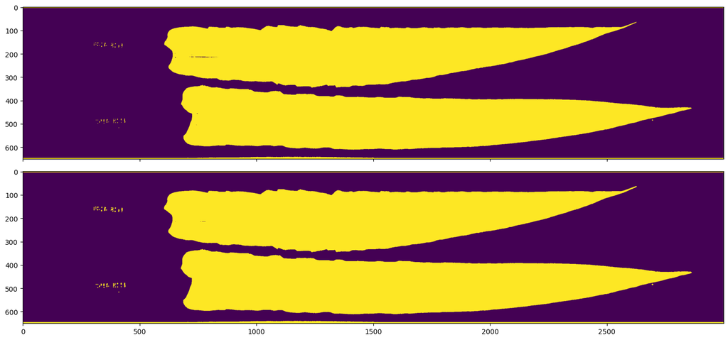

```python
# Add labels

its = 1
dilate2 = ndimage.binary_dilation(dilate, iterations=its)
fig, ax = plt.subplots(2,1, figsize=(15,7), sharex=True, sharey=True)
ax[0].imshow(dilate);
ax[1].imshow(dilate2);
fig.tight_layout();
```

If after dilating you still notice the holes, then you need to increase the iterations. What happens if you dilate too much?

### 2.4 Our second erosion (closing)

Let's erode (by the same number of iterations used in the second dilation), so that the blades go back to their original size.

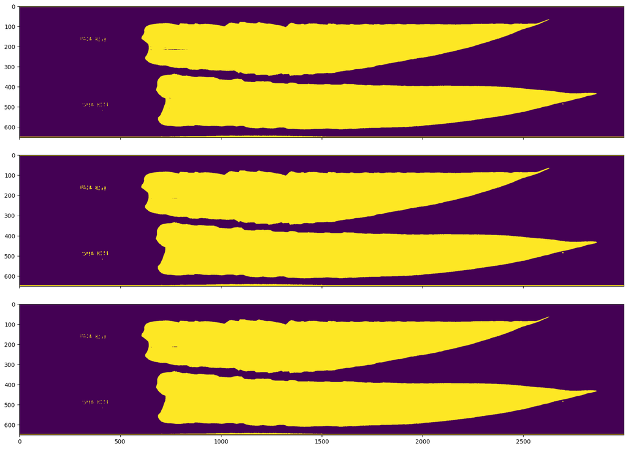

```python
# Add labels
erode2 = ndimage.binary_erosion(dilate2, iterations=its)
fig, ax = plt.subplots(3,1, figsize=(15,11), sharex=True, sharey=True)
ax[0].imshow(dilate);
ax[1].imshow(dilate2);
ax[2].imshow(erode2)
fig.tight_layout();
```

For the final image, we should have *closed* all the small holes. Compare the final image with our initial binary.

## Part 3: Finding connected components

Ultimately, our (retouched) binary has two separate leaves. Let's split this binary by looking at is connected components. Make sure you understand the following code.

```
Found 47 connected components
```

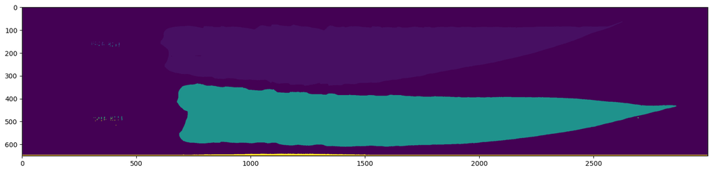

```python
# Different components correspond to different colors

label, num = ndimage.label(erode2)
print('Found', num,'connected components')
fig, ax = plt.subplots(1,1, figsize=(15,7), sharex=True, sharey=True)
ax.imshow(label);
fig.tight_layout();
```

We can also get the slices for each component

[output not shown]

[figure not shown]

```python
oss = ndimage.find_objects(label)
print(oss)
fig, ax = plt.subplots(len(oss),1, figsize=(15,5), sharex=False, sharey=False)
for i in range(len(ax)):
    ax[i].imshow(erode2[oss[i]]);
fig.tight_layout();
```

Notice that the slices `oss` only guarantee that the connected component will be contained. It does not prevent other connected componets to crash into the party. Let's fix that.

[figure not shown]

```python
# Make sure you understand the code

blades = [None for i in range(len(oss))]
for i in range(len(blades)):
    box = erode2[oss[i]].copy()
    box[label[oss[i]] != i+1] = 0
    box = np.pad(box, 25)
    blades[i] = box

fig, ax = plt.subplots(len(oss),1, figsize=(15,5), sharex=False, sharey=False)
for i in range(len(ax)):
    ax[i].imshow(blades[i]);
    ax[i].axis('off')
fig.tight_layout();
```

**Task**

Now that we have separated the blades, you can compute the surface area (in pixels) of each of them.

```python
# Your code
```

## Part 4: Getting borders

But what if we want the *perimeter* of each blade? We need to convolve by

$$\begin{bmatrix} -1 & -1 & -1 \\ -1 & +8 & -1 \\ -1 & -1 & -1 \end{bmatrix}.$$

Notice that if we are centered on an exterior pixel (background), we get $$-1*0-1*0-1*0-1*0+8*0-1*0-1*0-1*0-1*0 = 0.$$

If we are centered on an interior pixel (foreground), we also get: $$-1*1-1*1-1*1-1*1+8*1-1*1-1*1-1*1-1*1 = 0.$$

The only way we get something other than 0, is if we are on the border of the blade or right next to the border. Read carefully the following code and make sure you understand what's going on.

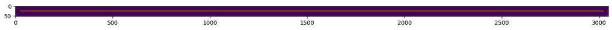

```python
border_kernel = np.array([
    [-1,-1,-1],
    [-1,8,-1],
    [-1,-1,-1]
])
border = ndimage.convolve(blades[0].astype(int), border_kernel)
border[border < 0] = 0
border[border > 0] = 1
border = border.astype(bool)

fig, ax = plt.subplots(1,1, figsize=(15,7), sharex=True, sharey=True)
ax.imshow(border);
fig.tight_layout();
```

Now it is your time to compute the perimeter of each blade.

```python
# Your code
```

## Assignment Wrap-up

Please fill out the form that appears when you run the code below. **You must completely fill this out in order to receive credit for the assignment!**

```python
HTML(
"""
<iframe
	src="https://forms.gle/APYRGfQpykSAnV7J8"
	width="800px"
	height="600px"
	frameborder="0"
	marginheight="0"
	marginwidth="0">
	Loading...
</iframe>
"""
)
```

[interactive chart not shown]

### Congratulations, you're done!

Submit this assignment by uploading it to the course Canvas web page. Go to the "Assignments" folder, find the appropriate submission folder link, and upload it there.

See you in class!

© Copyright 2025, Division of Plant Science & Technology—University of Missouri